# Super Learner for Applied Biostatisticians & Epidemiologists

# 14 Regression example (continuous outcome)

```r
set.seed(99)
n_reg <- 500
X_reg <- data.frame(x1 = rnorm(n_reg), x2 = rnorm(n_reg), x3 = rnorm(n_reg))
Y_reg <- with(X_reg, 3 + 2 * x1 + x1^2 - 1.5 * x2 * x3 + rnorm(n_reg, 0, 0.5))

set.seed(99)
sl_reg <- SuperLearner(
  Y = Y_reg, X = X_reg,
  family = gaussian(),
  SL.library = c("SL.mean", "SL.glm", "SL.glmnet",
                  "SL.randomForest", "SL.earth")
)
sl_reg
```

```
Call:
SuperLearner(Y = Y_reg, X = X_reg, family = gaussian(), SL.library = c("SL.mean",
    "SL.glm", "SL.glmnet", "SL.randomForest", "SL.earth"))

                     Risk   Coef
SL.mean_All         8.141 0.0000
SL.glm_All          4.198 0.0000
SL.glmnet_All       4.189 0.0000
SL.randomForest_All 2.010 0.2619
SL.earth_All        1.157 0.7381
```

```r
pred_reg <- predict(sl_reg, X_reg)

mse  <- mean((Y_reg - pred_reg$pred)^2)
cat("MSE :", round(mse, 4), "\n")
```

```
MSE : 0.2246
```

```r
cat("RMSE:", round(sqrt(mse), 4), "\n")
```

```
RMSE: 0.4739
```

**Note**

For continuous outcomes use `family = gaussian()` and the default `method.NNLS`; risk is reported as cross-validated mean squared error.

**What you see.** The ensemble MSE on the full data is 0.22 and the RMSE 0.47. In a regression context these are in-sample numbers because no external test set was carved out; treat them as a quick check that the pipeline runs without errors. A real regression report would split the data and report on the hold-out.

# 15 Dose-response estimation

A classic epidemiological problem (Naimi & Balzer, 2018) is estimating the *shape* of an exposure-outcome relationship when it is strongly non-linear: here, a piecewise curve with a discontinuity.

```r
set.seed(12345)
n_dose <- 1000
x_dose <- runif(n_dose, 0, 8)

# True dose-response: sqrt branch below 2, quadratic branch above 2
y_dose <- 5 + 4 * sqrt(9 * x_dose) * as.numeric(x_dose < 2) +
  as.numeric(x_dose >= 2) * (abs(x_dose - 6)^2) + rlaplace(n_dose)

D_dose <- data.frame(x = x_dose, y = y_dose)

# The true curve, to compare against
xl <- seq(0, 8, 0.1)
yl <- 5 + 4 * sqrt(9 * xl) * as.numeric(xl < 2) +
  as.numeric(xl >= 2) * (abs(xl - 6)^2)
truth_df <- data.frame(x = xl, y = yl)
```

```r
set.seed(123)

sl_dose <- SuperLearner(
  Y = D_dose$y, X = data.frame(x = D_dose$x),
  family = gaussian(),
  method = "method.NNLS",
  SL.library = c("SL.mean", "SL.glm", "SL.gam", "SL.earth")
)
sl_dose
```

```
Call:
SuperLearner(Y = D_dose$y, X = data.frame(x = D_dose$x), family = gaussian(),
    SL.library = c("SL.mean", "SL.glm", "SL.gam", "SL.earth"), method = "method.NNLS")

               Risk     Coef
SL.mean_All  29.895 0.000000
SL.glm_All   13.549 0.000000
SL.gam_All    9.776 0.006243
SL.earth_All  2.110 0.993757
```

```r
# Predict along a fine grid of "doses".
# onlySL = FALSE so library.predict keeps the genuine curve of every
# learner (with TRUE, zero-weight learners would be returned as 0)
pred_dose <- predict(sl_dose, data.frame(x = xl), onlySL = FALSE)
```

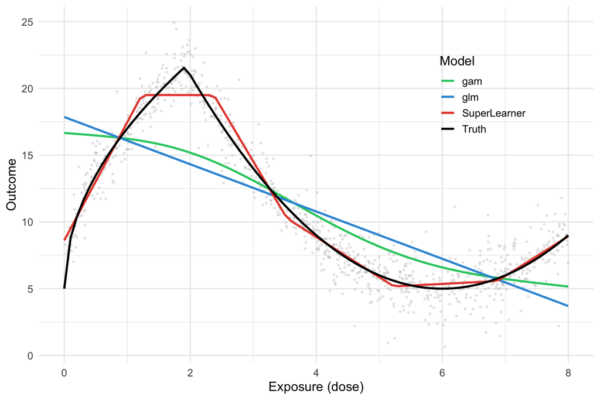

Dose-response curve: the Super Learner ensemble (here dominated by MARS) follows the non-linear truth more closely than the single GLM and GAM fits.

```r
# Column order matches SL.library: 1 = mean, 2 = glm, 3 = gam, 4 = earth
dose_df <- rbind(
  data.frame(x = xl, y = truth_df$y,              Model = "Truth"),
  data.frame(x = xl, y = pred_dose$pred,          Model = "SuperLearner"),
  data.frame(x = xl, y = pred_dose$library.predict[, 2], Model = "glm"),
  data.frame(x = xl, y = pred_dose$library.predict[, 3], Model = "gam")
)

ggplot() +
  geom_point(data = D_dose, aes(x, y),
             color = "gray75", alpha = 0.3, size = 0.6) +
  geom_line(data = dose_df, aes(x, y, color = Model), size = 1.1) +
  scale_color_manual(values = c(Truth = "black", SuperLearner = "#E74C3C",
                                 glm = "#3498DB", gam = "#2ECC71")) +
  labs(x = "Exposure (dose)", y = "Outcome") +
  theme_minimal(base_size = 14) +
  theme(legend.position = c(0.8, 0.75))
```

**Tip**

A flexible learner combination (`SL.gam`, `SL.earth`) lets SL track strongly non-linear dose-response shapes without *a priori* specification of the functional form. That is what makes it useful for exposure-response analyses.

# 16 Comparison: SuperLearner vs caret

```r
set.seed(42)

ctrl <- trainControl(method = "cv", number = 5, classProbs = TRUE,
                     summaryFunction = twoClassSummary)

Y_train_factor <- factor(ifelse(Y_train == 1, "Case", "Control"),
                         levels = c("Control", "Case"))

system.time({
  caret_fit <- train(
    x = X_train, y = Y_train_factor,
    method = "glmnet",
    trControl = ctrl,
    metric = "ROC",
    tuneLength = 5
  )
})
```

```
   user  system elapsed
  0.541   0.008   0.559
```

```r
cat("Best caret cross-validated AUC :", round(max(caret_fit$results$ROC), 4), "\n")
```

```
Best caret cross-validated AUC : 0.832
```

```r
cat("SuperLearner test AUC          :", round(auc_sl, 4), "\n")
```

```
SuperLearner test AUC          : 0.8413
```

```r
cat("(caret uses 5-fold CV on the training set; SuperLearner is reported on the held-out test set)\n")
```

```
(caret uses 5-fold CV on the training set; SuperLearner is reported on the held-out test set)
```

**What you see.** caret’s 5-fold CV on the training data yields an AUC of 0.832 for a tuned LASSO; the SuperLearner ensemble evaluated on the independent test set reaches 0.841. The numbers are on different scales (internal CV vs external test), but the ordering is consistent: the ensemble does not lose ground to a well-tuned single learner, and it brings the extra structure that caret’s single-model pipeline does not.

**What SL adds over caret:**

1. No need to pick a single best model, since SL builds the ensemble automatically;
2. Valid risk estimation for the ensemble itself (`CV.SuperLearner`);
3. A theoretical guarantee of asymptotic optimality;
4. Integrated feature screening and hyperparameter grids;
5. A direct bridge to causal inference (TMLE, AIPW).

# 17 Summary table

```r
summary_table <- data.frame(
  Approach = c("Single learner", "SuperLearner", "CV.SuperLearner"),
  Ensemble = c("No", "Yes", "Yes"),
  Performance_estimate = c("Over-optimistic (in-sample)", "Internal CV (per learner)",
                           "Valid (external CV of ensemble)"),
  Typical_use = c("Baseline / benchmark", "Final prediction model",
                  "Reported accuracy / publication")
)
knitr::kable(summary_table,
             caption = "Comparing the three estimation strategies in this tutorial.")
```

Comparing the three estimation strategies in this tutorial.

| Approach | Ensemble | Performance_estimate | Typical_use |
| --- | --- | --- | --- |
| Single learner | No | Over-optimistic (in-sample) | Baseline / benchmark |
| SuperLearner | Yes | Internal CV (per learner) | Final prediction model |
| CV.SuperLearner | Yes | Valid (external CV of ensemble) | Reported accuracy / publication |

# 18 Best practices for epidemiologists

## 18.1 1. Curate the library

At a minimum include:

- **`SL.glm`** - logistic regression (the epidemiological reference);
- **`SL.glmnet`** - penalised regression (high-dimensional settings);
- **`SL.randomForest`** / **`SL.ranger`** - ensemble of trees;
- **`SL.xgboost`** - gradient boosting;
- **`SL.earth`** / **`SL.gam`** - smooth non-linear flexibility;
- **`SL.mean`** - the benchmark every learner must beat.

**Why and how.** Every library you build will start from this skeleton. The rationale is simple: you want at least one linear, one penalised linear, one tree ensemble, one booster, one flexible spline, and the benchmark. The exact names are the ones that ship with SuperLearner and work on every platform; if you later discover a better learner for your domain (e.g., a specialised survival wrapper), you add it, you do not remove the basics.

## 18.2 2. Always use CV.SuperLearner for reported results

**Why and how.** `CV.SuperLearner()` alone yields a **valid** estimate of ensemble performance. `SuperLearner()` does not. The difference is the outer CV layer: the former estimates what the ensemble will do on new patients; the latter estimates what its ingredients did on the training folds, which is optimistic by construction. When a paper or a protocol asks for “the SuperLearner AUC”, you run `CV.SuperLearner()` and cite its summary.

## 18.3 3. Explore hyperparameters for the key algorithms

```r
rf_learners <- create.Learner("SL.randomForest",
                              tune = list(mtry = c(3, 5, 7)))
xgb_learners <- create.Learner("SL.xgboost", tune = list(
  ntrees = c(500, 1000), max_depth = 3:4, shrinkage = c(0.01, 0.1)
))
```

## 18.4 4. Screen when p is large

**Why and how.** The `list()` syntax pairs learners with screeners, and every pair becomes a separate library member. The three-row template below is a complete starting library for a wide genomic or EHR data set: an unscreened LASSO, a correlation-screened LASSO, and a correlation-rank-screened forest. Expand the ranks as the dimension grows.

```r
SL.library <- list(
  "SL.glmnet",
  c("SL.glmnet", "screen.corP"),
  c("SL.randomForest", "screen.corRank5")
)
```

## 18.5 5. Enable parallel computing

**Why and how.** Two lines enable all cores on a single machine: `options(mc.cores = ...)` reads the core count once, and `set.seed(1, "L'Ecuyer-CMRG")` installs a parallel-safe random stream. Put these at the top of every script that calls `CV.SuperLearner()` or `mcSuperLearner()` with `parallel = "multicore"`.

```r
options(mc.cores = RhpcBLASctl::get_num_cores())
set.seed(1, "L'Ecuyer-CMRG")   # reproducibility across cores
```

## 18.6 6. Bridge to causal inference with TMLE

**Why and how.** The TMLE workflow takes two SuperLearner libraries: one for the outcome regression `Q` and one for the propensity score `g`. The pattern below is the recommended starting point: a rich library for `Q` and a simpler, well-behaved one for `g` (propensity scores are delicate and benefit from fewer, more stable learners). Uncomment and supply your own `Y`, `A`, `W` to run it.

```r
library(tmle)

tmle_fit <- tmle(
  Y = Y, A = A, W = W,
  Q.SL.library = c("SL.glm", "SL.glmnet", "SL.randomForest", "SL.xgboost"),
  g.SL.library = c("SL.glm", "SL.glmnet"),
  cvControl = list(V = 5)
)
```

**Warning**

Super Learner (or a library of ≥ 15 flexible algorithms) is the *recommended* estimator for the nuisance parameters of TMLE and double-robust methods. It keeps the model free of the “unrealistic modeling assumptions” that modern causal inference is trying to avoid.

# 19 Quick reference cheat sheet

```r
cheat <- data.frame(
  Function = c("SuperLearner()", "CV.SuperLearner()", "mcSuperLearner()",
               "create.Learner()", "predict()", "coef()", "summary()",
               "plot()"),
  Purpose = c(
    "Fit SL (no valid ensemble performance estimate)",
    "Fit SL inside external CV (valid performance for reporting)",
    "Parallel SL fit",
    "Generate hyperparameter variants of a learner",
    "Generate predictions on new data",
    "Extract the ensemble weights",
    "Tabular CV performance summary",
    "Plot CV risk with confidence intervals"
  )
)
knitr::kable(cheat, caption = "SuperLearner function reference.")
```

SuperLearner function reference.

| Function | Purpose |
| --- | --- |
| SuperLearner() | Fit SL (no valid ensemble performance estimate) |
| CV.SuperLearner() | Fit SL inside external CV (valid performance for reporting) |
| mcSuperLearner() | Parallel SL fit |
| create.Learner() | Generate hyperparameter variants of a learner |
| predict() | Generate predictions on new data |
| coef() | Extract the ensemble weights |
| summary() | Tabular CV performance summary |
| plot() | Plot CV risk with confidence intervals |

# 21 References

## 21.1 Super Learner and ensemble learning

1. Wolpert DH (1992). Stacked generalization. *Neural Networks*, 5(2):241-259.
2. Breiman L (2001). Statistical modeling: The two cultures. *Statistical Science*, 16(3):199-231.
3. van der Laan MJ, Polley EC, Hubbard AE (2007). Super Learner. *Statistical Applications in Genetics and Molecular Biology*, 6(1), Article 25.
4. Polley EC, van der Laan MJ (2010). Super Learner Prediction. U.C. Berkeley Division of Biostatistics Working Paper 266.
5. Polley EC (2010). *Super Learner Prediction*. PhD thesis, University of California, Berkeley.
6. Kuncheva LI (2004). *Combining Pattern Classifiers: Methods and Algorithms*. Wiley.
7. Naimi AI, Balzer LB (2018). Stacked Generalization: An Introduction to Super Learning. *European Journal of Epidemiology*, 33(5):459-464.

## 21.2 Applications in epidemiology, clinical and personalized medicine

8. Rose S (2013). Mortality risk score prediction in an elderly population using machine learning. *American Journal of Epidemiology*, 178(7):972-980.
9. Pirracchio R, Petersen ML, Carone M, Rigon MR, Chevret S, van der Laan MJ (2015). Mortality prediction in the ICU based on the Super Learner algorithm: a retrospective cohort study. *Critical Care Medicine*, 43(6):1159-1176.
10. Obermeyer Z, Emanuel EJ (2016). Predicting the future: big data, machine learning, and clinical medicine. *New England Journal of Medicine*, 375(13):1216-1219.
11. Beam AL, Kohane IS (2018). Big data and machine learning in health care. *JAMA*, 319(13):1317-1318.

## 21.3 Practice, targeted learning and causal inference

12. Phillips RV, van der Laan MJ, Lee H, Gruber S (2023). Practical considerations for specifying a Super Learner. *International Journal of Epidemiology*, 52(4):1276-1285.
13. van der Laan MJ, Rose S (2011). *Targeted Learning: Causal Inference for Observational and Experimental Data*. Springer.
14. van der Laan MJ, Rose S (2018). *Targeted Learning in Data Science: Causal Inference for Complex Longitudinal Data*. Springer.

**Super Learner for Applied Biostatisticians & Epidemiologists**  
Miguel Angel Luque-Fernández · Dpto. Estadística e Investigación Operativa · Universidad de Granada · https://migariane.github.io

**License: CC BY 4.0.** You are free to share and adapt this tutorial with attribution.

Teaching materials by E. Polley, S. Rose, C. Kennedy, A. Naimi and L. Balzer, and the SuperLearner package documentation, informed the worked examples; the text, code and structure are the author’s own. All code executes in a single pass, and results are reproducible with the seeds given in each chunk.